# R Notebook

## Variables for final model

To make our model more complex and improve than before, we decided to include more variables in our model. Therefore, we tried systematic methods to select variables that we use in final model at first. Among 44 candidate variables, we arbitrarily choose top 28 important variables whose importance was measured by Random Forest.

```r
# plot dataframe
ggplot(feat_imp_df, aes(x = reorder(feature, IncNodePurity),
                         y = IncNodePurity)) +
    geom_bar(stat='identity') +
    geom_vline(xintercept = 15.5, color = "red")+
    coord_flip() +
    theme_classic() +
    labs(
      x   = "Feature",
      y   = "Importance",
      title = "Feature Importance: <RF>"
    )
```

[output not shown]

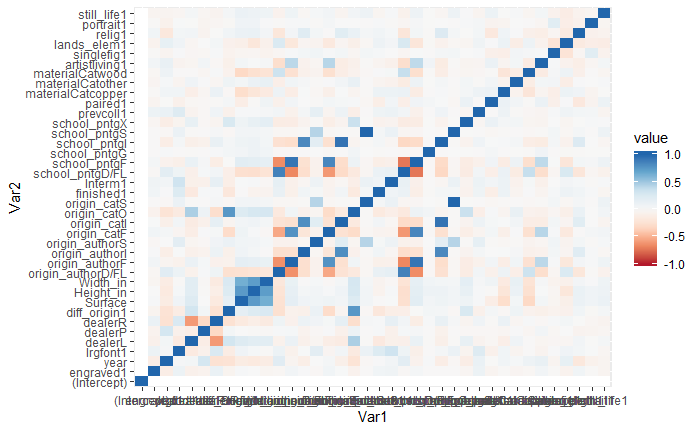

In above plot which indicates correlation between predictor variables, we could find `school_pntg`, `origin_cat` and `origin_author` are correlated each other closely. Moreover, `Height_in`, `Width_in`, and `Surface` are also correlated closely. Therefore, we decided to exclude simliar variables `school_pntg` and `origin_author` and keep `origin_cat`. Among `Surface`, `Width_in`, and `Height_in`, we decided to keep `Surface` because we thought that `Surface` can represent the others well. As a result, selected variables for final models are shown below:

selected variable by RF, EDA, and correlation check

| engraved | origin_cat | artistliving |
| --- | --- | --- |
| year | finished | singlefig |
| lrgfont | Interm | lands_elem |
| dealer | prevcoll | relig |
| diff_origin | paired | portrait |
| Surface | materialCat | still_life |